# Risk Factor Analysis

## Outcome Variable

**Outcome Variable:** stunted

## Predictor Variables

**Intervention Variable:** hdlvry

**Adjustment Set:**

- arm
- sex
- W_mage
- meducyrs
- feducyrs
- hhwealth_quart
- hfoodsec
- W_nrooms
- brthmon
- impfloor
- impsan
- safeh20
- delta_W_mage
- delta_meducyrs
- delta_feducyrs
- delta_hhwealth_quart
- delta_hfoodsec
- delta_W_nrooms
- delta_brthmon
- delta_impfloor
- delta_impsan
- delta_safeh20

## Stratifying Variables

The analysis was stratified on these variable(s):

- agecat
- studyid
- country

## Data Summary

| agecat | studyid | country | hdlvry | stunted | n_cell | n |
| --- | --- | --- | --- | --- | --- | --- |
| Birth | ki1000108-CMC-V-BCS-2002 | INDIA | 0 | 0 | 74 | 90 |
| Birth | ki1000108-CMC-V-BCS-2002 | INDIA | 0 | 1 | 16 | 90 |
| Birth | ki1000108-CMC-V-BCS-2002 | INDIA | 1 | 0 | 0 | 90 |
| Birth | ki1000108-CMC-V-BCS-2002 | INDIA | 1 | 1 | 0 | 90 |
| Birth | ki1000108-IRC | INDIA | 0 | 0 | 337 | 388 |
| Birth | ki1000108-IRC | INDIA | 0 | 1 | 44 | 388 |
| Birth | ki1000108-IRC | INDIA | 1 | 0 | 6 | 388 |
| Birth | ki1000108-IRC | INDIA | 1 | 1 | 1 | 388 |
| Birth | ki1000109-EE | PAKISTAN | 0 | 0 | 2 | 4 |
| Birth | ki1000109-EE | PAKISTAN | 0 | 1 | 2 | 4 |
| Birth | ki1000109-EE | PAKISTAN | 1 | 0 | 0 | 4 |
| Birth | ki1000109-EE | PAKISTAN | 1 | 1 | 0 | 4 |
| Birth | ki1000304b-SAS-CompFeed | INDIA | 0 | 0 | 6 | 180 |
| Birth | ki1000304b-SAS-CompFeed | INDIA | 0 | 1 | 5 | 180 |
| Birth | ki1000304b-SAS-CompFeed | INDIA | 1 | 0 | 129 | 180 |
| Birth | ki1000304b-SAS-CompFeed | INDIA | 1 | 1 | 40 | 180 |
| Birth | ki1017093c-NIH-Crypto | BANGLADESH | 0 | 0 | 18 | 27 |
| Birth | ki1017093c-NIH-Crypto | BANGLADESH | 0 | 1 | 4 | 27 |
| Birth | ki1017093c-NIH-Crypto | BANGLADESH | 1 | 0 | 4 | 27 |
| Birth | ki1017093c-NIH-Crypto | BANGLADESH | 1 | 1 | 1 | 27 |
| Birth | ki1135781-COHORTS | INDIA | 0 | 0 | 2613 | 4694 |
| Birth | ki1135781-COHORTS | INDIA | 0 | 1 | 325 | 4694 |
| Birth | ki1135781-COHORTS | INDIA | 1 | 0 | 1534 | 4694 |
| Birth | ki1135781-COHORTS | INDIA | 1 | 1 | 222 | 4694 |
| Birth | kiGH5241-JiVitA-3 | BANGLADESH | 0 | 0 | 12 | 600 |
| Birth | kiGH5241-JiVitA-3 | BANGLADESH | 0 | 1 | 10 | 600 |
| Birth | kiGH5241-JiVitA-3 | BANGLADESH | 1 | 0 | 426 | 600 |
| Birth | kiGH5241-JiVitA-3 | BANGLADESH | 1 | 1 | 152 | 600 |
| Birth | kiGH5241-JiVitA-4 | BANGLADESH | 0 | 0 | 74 | 1640 |
| Birth | kiGH5241-JiVitA-4 | BANGLADESH | 0 | 1 | 20 | 1640 |

[output cut: 86 more lines]

The following strata were considered:

- agecat: 24 months, studyid: ki1000108-CMC-V-BCS-2002, country: INDIA
- agecat: 24 months, studyid: ki1000108-IRC, country: INDIA
- agecat: 24 months, studyid: ki1017093b-PROVIDE, country: BANGLADESH
- agecat: 24 months, studyid: ki1017093c-NIH-Crypto, country: BANGLADESH
- agecat: 24 months, studyid: ki1066203-TanzaniaChild2, country: TANZANIA, UNITED REPUBLIC OF
- agecat: 24 months, studyid: ki1113344-GMS-Nepal, country: NEPAL
- agecat: 24 months, studyid: ki1135781-COHORTS, country: INDIA
- agecat: 24 months, studyid: kiGH5241-JiVitA-3, country: BANGLADESH
- agecat: 24 months, studyid: kiGH5241-JiVitA-4, country: BANGLADESH
- agecat: 6 months, studyid: ki1000108-CMC-V-BCS-2002, country: INDIA
- agecat: 6 months, studyid: ki1000108-IRC, country: INDIA
- agecat: 6 months, studyid: ki1000109-EE, country: PAKISTAN
- agecat: 6 months, studyid: ki1000304b-SAS-CompFeed, country: INDIA
- agecat: 6 months, studyid: ki1000304b-SAS-FoodSuppl, country: INDIA
- agecat: 6 months, studyid: ki1017093b-PROVIDE, country: BANGLADESH
- agecat: 6 months, studyid: ki1017093c-NIH-Crypto, country: BANGLADESH
- agecat: 6 months, studyid: ki1066203-TanzaniaChild2, country: TANZANIA, UNITED REPUBLIC OF
- agecat: 6 months, studyid: ki1113344-GMS-Nepal, country: NEPAL
- agecat: 6 months, studyid: ki1135781-COHORTS, country: INDIA
- agecat: 6 months, studyid: kiGH5241-JiVitA-3, country: BANGLADESH
- agecat: 6 months, studyid: kiGH5241-JiVitA-4, country: BANGLADESH
- agecat: Birth, studyid: ki1000108-CMC-V-BCS-2002, country: INDIA
- agecat: Birth, studyid: ki1000108-IRC, country: INDIA
- agecat: Birth, studyid: ki1000109-EE, country: PAKISTAN
- agecat: Birth, studyid: ki1000304b-SAS-CompFeed, country: INDIA
- agecat: Birth, studyid: ki1017093c-NIH-Crypto, country: BANGLADESH
- agecat: Birth, studyid: ki1135781-COHORTS, country: INDIA
- agecat: Birth, studyid: kiGH5241-JiVitA-3, country: BANGLADESH
- agecat: Birth, studyid: kiGH5241-JiVitA-4, country: BANGLADESH

### Dropped Strata

Some strata were dropped due to rare outcomes:

- agecat: Birth, studyid: ki1000108-CMC-V-BCS-2002, country: INDIA
- agecat: Birth, studyid: ki1000108-IRC, country: INDIA
- agecat: Birth, studyid: ki1000109-EE, country: PAKISTAN
- agecat: Birth, studyid: ki1017093c-NIH-Crypto, country: BANGLADESH
- agecat: 6 months, studyid: ki1000108-CMC-V-BCS-2002, country: INDIA
- agecat: 6 months, studyid: ki1000108-IRC, country: INDIA
- agecat: 24 months, studyid: ki1000108-CMC-V-BCS-2002, country: INDIA
- agecat: 24 months, studyid: ki1000108-IRC, country: INDIA
- agecat: 24 months, studyid: ki1066203-TanzaniaChild2, country: TANZANIA, UNITED REPUBLIC OF

## Methods Detail

We’re interested in the causal parameters $E[Y_a]$ for all values of $a \in \mathcal{A}$. These parameters represent the mean outcome if, possibly contrary to fact, we intervened to set all units to have $A=a$. Under the randomization and positivity assumptions, these are identified by the statistical parameters $\psi_a=E_W[E_{Y|A,W}(Y|A=a,W)]$. In addition, we’re interested in the mean of $Y$, $E[Y]$ under no intervention (the observed mean). We will estimate these parameters by using SuperLearner to fit the relevant likelihood factors – $E_{Y|A,W}(Y|A=a,W)$ and $p(A=a|W)$, and then updating our likelihood fit using a joint TMLE.

For unadjusted analyses ($W=\{\}$), initial likelihoods were estimated using Lrnr_glm to estimate the simple $E(Y|A)$ and Lrnr_mean to estimate $p(A)$. For adjusted analyses, a small library containing Lrnr_glmnet, Lrnr_xgboost, and Lrnr_mean was used.

Having estimated these parameters, we will then use the delta method to estimate relative risks and attributable risks relative to a prespecified baseline level of $A$.

# Results Detail

## Results Plots

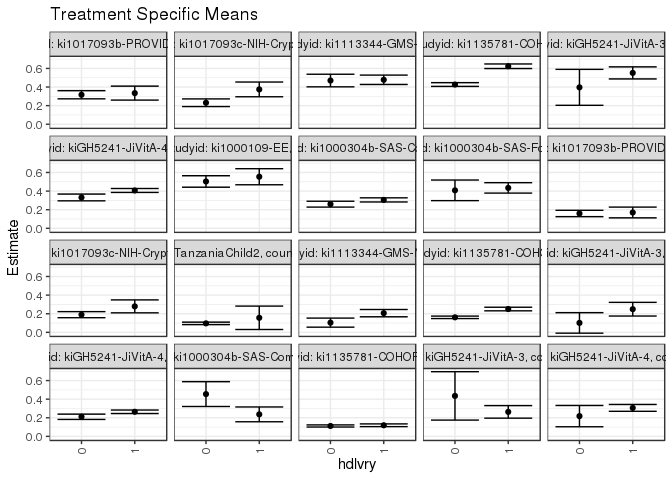

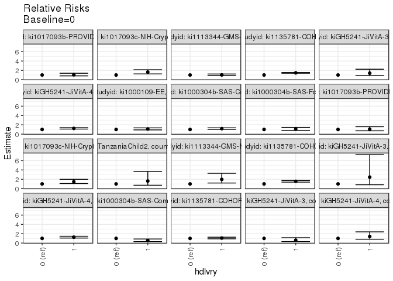

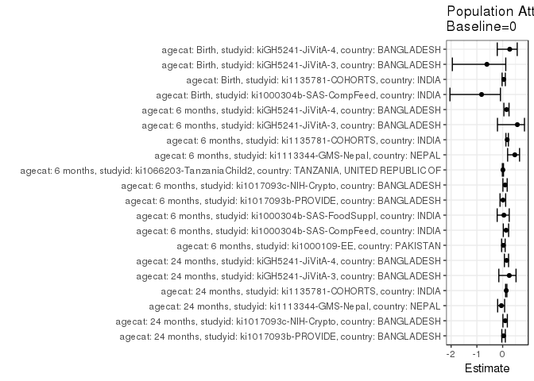

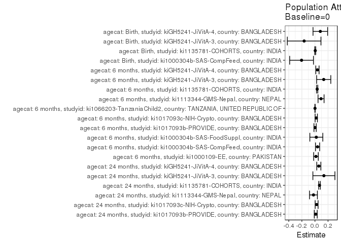

## Results Table

### Parameter: TSM

| agecat | studyid | country | intervention_level | baseline_level | estimate | ci_lower | ci_upper |
| --- | --- | --- | --- | --- | --- | --- | --- |
| Birth | ki1000304b-SAS-CompFeed | INDIA | 0 | NA | 0.4545455 | 0.3211332 | 0.5879577 |
| Birth | ki1000304b-SAS-CompFeed | INDIA | 1 | NA | 0.2366864 | 0.1571441 | 0.3162286 |
| Birth | ki1135781-COHORTS | INDIA | 0 | NA | 0.1116181 | 0.1002252 | 0.1230111 |
| Birth | ki1135781-COHORTS | INDIA | 1 | NA | 0.1192336 | 0.1045591 | 0.1339082 |
| Birth | kiGH5241-JiVitA-3 | BANGLADESH | 0 | NA | 0.4350723 | 0.1748720 | 0.6952726 |
| Birth | kiGH5241-JiVitA-3 | BANGLADESH | 1 | NA | 0.2633272 | 0.1958485 | 0.3308060 |
| Birth | kiGH5241-JiVitA-4 | BANGLADESH | 0 | NA | 0.2177916 | 0.1033324 | 0.3322509 |
| Birth | kiGH5241-JiVitA-4 | BANGLADESH | 1 | NA | 0.3062072 | 0.2695015 | 0.3429128 |
| 6 months | ki1000109-EE | PAKISTAN | 0 | NA | 0.5033407 | 0.4416502 | 0.5650313 |
| 6 months | ki1000109-EE | PAKISTAN | 1 | NA | 0.5542561 | 0.4678640 | 0.6406481 |
| 6 months | ki1000304b-SAS-CompFeed | INDIA | 0 | NA | 0.2594468 | 0.2278773 | 0.2910164 |
| 6 months | ki1000304b-SAS-CompFeed | INDIA | 1 | NA | 0.3050885 | 0.2828134 | 0.3273637 |
| 6 months | ki1000304b-SAS-FoodSuppl | INDIA | 0 | NA | 0.4078947 | 0.2972611 | 0.5185283 |
| 6 months | ki1000304b-SAS-FoodSuppl | INDIA | 1 | NA | 0.4342105 | 0.3784199 | 0.4900011 |
| 6 months | ki1017093b-PROVIDE | BANGLADESH | 0 | NA | 0.1590812 | 0.1248539 | 0.1933086 |
| 6 months | ki1017093b-PROVIDE | BANGLADESH | 1 | NA | 0.1697973 | 0.1120414 | 0.2275532 |
| 6 months | ki1017093c-NIH-Crypto | BANGLADESH | 0 | NA | 0.1896454 | 0.1570480 | 0.2222429 |
| 6 months | ki1017093c-NIH-Crypto | BANGLADESH | 1 | NA | 0.2789873 | 0.2093810 | 0.3485936 |
| 6 months | ki1066203-TanzaniaChild2 | TANZANIA, UNITED REPUBLIC OF | 0 | NA | 0.0963473 | 0.0830377 | 0.1096569 |
| 6 months | ki1066203-TanzaniaChild2 | TANZANIA, UNITED REPUBLIC OF | 1 | NA | 0.1562500 | 0.0304145 | 0.2820855 |
| 6 months | ki1113344-GMS-Nepal | NEPAL | 0 | NA | 0.1041789 | 0.0553838 | 0.1529741 |
| 6 months | ki1113344-GMS-Nepal | NEPAL | 1 | NA | 0.2061116 | 0.1669892 | 0.2452339 |
| 6 months | ki1135781-COHORTS | INDIA | 0 | NA | 0.1612357 | 0.1478778 | 0.1745935 |
| 6 months | ki1135781-COHORTS | INDIA | 1 | NA | 0.2503326 | 0.2309941 | 0.2696710 |
| 6 months | kiGH5241-JiVitA-3 | BANGLADESH | 0 | NA | 0.1012802 | -0.0088882 | 0.2114486 |
| 6 months | kiGH5241-JiVitA-3 | BANGLADESH | 1 | NA | 0.2487127 | 0.1751852 | 0.3222402 |
| 6 months | kiGH5241-JiVitA-4 | BANGLADESH | 0 | NA | 0.2106603 | 0.1822099 | 0.2391107 |
| 6 months | kiGH5241-JiVitA-4 | BANGLADESH | 1 | NA | 0.2642727 | 0.2454281 | 0.2831173 |
| 24 months | ki1017093b-PROVIDE | BANGLADESH | 0 | NA | 0.3170984 | 0.2733031 | 0.3608936 |
| 24 months | ki1017093b-PROVIDE | BANGLADESH | 1 | NA | 0.3345908 | 0.2594066 | 0.4097749 |
| 24 months | ki1017093c-NIH-Crypto | BANGLADESH | 0 | NA | 0.2311937 | 0.1898925 | 0.2724949 |
| 24 months | ki1017093c-NIH-Crypto | BANGLADESH | 1 | NA | 0.3746183 | 0.2956385 | 0.4535980 |
| 24 months | ki1113344-GMS-Nepal | NEPAL | 0 | NA | 0.4700816 | 0.4023040 | 0.5378592 |
| 24 months | ki1113344-GMS-Nepal | NEPAL | 1 | NA | 0.4779622 | 0.4276408 | 0.5282837 |
| 24 months | ki1135781-COHORTS | INDIA | 0 | NA | 0.4268495 | 0.4067984 | 0.4469007 |
| 24 months | ki1135781-COHORTS | INDIA | 1 | NA | 0.6236860 | 0.5990557 | 0.6483163 |
| 24 months | kiGH5241-JiVitA-3 | BANGLADESH | 0 | NA | 0.3967324 | 0.2036721 | 0.5897926 |
| 24 months | kiGH5241-JiVitA-3 | BANGLADESH | 1 | NA | 0.5520699 | 0.4872118 | 0.6169281 |
| 24 months | kiGH5241-JiVitA-4 | BANGLADESH | 0 | NA | 0.3313801 | 0.2949409 | 0.3678194 |
| 24 months | kiGH5241-JiVitA-4 | BANGLADESH | 1 | NA | 0.4066039 | 0.3853706 | 0.4278371 |

### Parameter: E(Y)

| agecat | studyid | country | intervention_level | baseline_level | estimate | ci_lower | ci_upper |
| --- | --- | --- | --- | --- | --- | --- | --- |
| Birth | ki1000304b-SAS-CompFeed | INDIA | NA | NA | 0.2500000 | 0.1698155 | 0.3301845 |
| Birth | ki1135781-COHORTS | INDIA | NA | NA | 0.1165317 | 0.1073518 | 0.1257117 |
| Birth | kiGH5241-JiVitA-3 | BANGLADESH | NA | NA | 0.2700000 | 0.2043793 | 0.3356207 |
| Birth | kiGH5241-JiVitA-4 | BANGLADESH | NA | NA | 0.3000000 | 0.2644043 | 0.3355957 |
| 6 months | ki1000109-EE | PAKISTAN | NA | NA | 0.5189189 | 0.4679396 | 0.5698982 |
| 6 months | ki1000304b-SAS-CompFeed | INDIA | NA | NA | 0.2997250 | 0.2767096 | 0.3227405 |
| 6 months | ki1000304b-SAS-FoodSuppl | INDIA | NA | NA | 0.4289474 | 0.3791199 | 0.4787748 |
| 6 months | ki1017093b-PROVIDE | BANGLADESH | NA | NA | 0.1612350 | 0.1313580 | 0.1911120 |
| 6 months | ki1017093c-NIH-Crypto | BANGLADESH | NA | NA | 0.2097902 | 0.1799252 | 0.2396552 |
| 6 months | ki1066203-TanzaniaChild2 | TANZANIA, UNITED REPUBLIC OF | NA | NA | 0.0973451 | 0.0840860 | 0.1106043 |
| 6 months | ki1113344-GMS-Nepal | NEPAL | NA | NA | 0.1973435 | 0.1633315 | 0.2313554 |
| 6 months | ki1135781-COHORTS | INDIA | NA | NA | 0.1955735 | 0.1842315 | 0.2069155 |
| 6 months | kiGH5241-JiVitA-3 | BANGLADESH | NA | NA | 0.2352941 | 0.1668442 | 0.3037440 |
| 6 months | kiGH5241-JiVitA-4 | BANGLADESH | NA | NA | 0.2486982 | 0.2326357 | 0.2647607 |
| 24 months | ki1017093b-PROVIDE | BANGLADESH | NA | NA | 0.3292894 | 0.2909105 | 0.3676684 |
| 24 months | ki1017093c-NIH-Crypto | BANGLADESH | NA | NA | 0.2568093 | 0.2190047 | 0.2946140 |
| 24 months | ki1113344-GMS-Nepal | NEPAL | NA | NA | 0.4475375 | 0.4023913 | 0.4926837 |
| 24 months | ki1135781-COHORTS | INDIA | NA | NA | 0.4964878 | 0.4800590 | 0.5129165 |
| 24 months | kiGH5241-JiVitA-3 | BANGLADESH | NA | NA | 0.5335628 | 0.4674074 | 0.5997182 |
| 24 months | kiGH5241-JiVitA-4 | BANGLADESH | NA | NA | 0.3907500 | 0.3719518 | 0.4095482 |

### Parameter: RR

| agecat | studyid | country | intervention_level | baseline_level | estimate | ci_lower | ci_upper |
| --- | --- | --- | --- | --- | --- | --- | --- |
| Birth | ki1000304b-SAS-CompFeed | INDIA | 0 | 0 | 1.0000000 | 1.0000000 | 1.0000000 |
| Birth | ki1000304b-SAS-CompFeed | INDIA | 1 | 0 | 0.5207101 | 0.3121948 | 0.8684928 |
| Birth | ki1135781-COHORTS | INDIA | 0 | 0 | 1.0000000 | 1.0000000 | 1.0000000 |
| Birth | ki1135781-COHORTS | INDIA | 1 | 0 | 1.0682282 | 0.9106873 | 1.2530223 |
| Birth | kiGH5241-JiVitA-3 | BANGLADESH | 0 | 0 | 1.0000000 | 1.0000000 | 1.0000000 |
| Birth | kiGH5241-JiVitA-3 | BANGLADESH | 1 | 0 | 0.6052493 | 0.3189239 | 1.1486339 |
| Birth | kiGH5241-JiVitA-4 | BANGLADESH | 0 | 0 | 1.0000000 | 1.0000000 | 1.0000000 |
| Birth | kiGH5241-JiVitA-4 | BANGLADESH | 1 | 0 | 1.4059638 | 0.8223815 | 2.4036706 |
| 6 months | ki1000109-EE | PAKISTAN | 0 | 0 | 1.0000000 | 1.0000000 | 1.0000000 |
| 6 months | ki1000109-EE | PAKISTAN | 1 | 0 | 1.1011548 | 0.9030164 | 1.3427685 |
| 6 months | ki1000304b-SAS-CompFeed | INDIA | 0 | 0 | 1.0000000 | 1.0000000 | 1.0000000 |
| 6 months | ki1000304b-SAS-CompFeed | INDIA | 1 | 0 | 1.1759194 | 1.0239057 | 1.3505016 |
| 6 months | ki1000304b-SAS-FoodSuppl | INDIA | 0 | 0 | 1.0000000 | 1.0000000 | 1.0000000 |
| 6 months | ki1000304b-SAS-FoodSuppl | INDIA | 1 | 0 | 1.0645161 | 0.7885142 | 1.4371264 |
| 6 months | ki1017093b-PROVIDE | BANGLADESH | 0 | 0 | 1.0000000 | 1.0000000 | 1.0000000 |
| 6 months | ki1017093b-PROVIDE | BANGLADESH | 1 | 0 | 1.0673625 | 0.7142240 | 1.5951055 |
| 6 months | ki1017093c-NIH-Crypto | BANGLADESH | 0 | 0 | 1.0000000 | 1.0000000 | 1.0000000 |
| 6 months | ki1017093c-NIH-Crypto | BANGLADESH | 1 | 0 | 1.4710993 | 1.0869446 | 1.9910242 |
| 6 months | ki1066203-TanzaniaChild2 | TANZANIA, UNITED REPUBLIC OF | 0 | 0 | 1.0000000 | 1.0000000 | 1.0000000 |
| 6 months | ki1066203-TanzaniaChild2 | TANZANIA, UNITED REPUBLIC OF | 1 | 0 | 1.6217376 | 0.7163325 | 3.6715252 |
| 6 months | ki1113344-GMS-Nepal | NEPAL | 0 | 0 | 1.0000000 | 1.0000000 | 1.0000000 |
| 6 months | ki1113344-GMS-Nepal | NEPAL | 1 | 0 | 1.9784383 | 1.1932462 | 3.2803107 |
| 6 months | ki1135781-COHORTS | INDIA | 0 | 0 | 1.0000000 | 1.0000000 | 1.0000000 |
| 6 months | ki1135781-COHORTS | INDIA | 1 | 0 | 1.5525878 | 1.3871591 | 1.7377452 |
| 6 months | kiGH5241-JiVitA-3 | BANGLADESH | 0 | 0 | 1.0000000 | 1.0000000 | 1.0000000 |
| 6 months | kiGH5241-JiVitA-3 | BANGLADESH | 1 | 0 | 2.4556893 | 0.8278288 | 7.2846101 |
| 6 months | kiGH5241-JiVitA-4 | BANGLADESH | 0 | 0 | 1.0000000 | 1.0000000 | 1.0000000 |
| 6 months | kiGH5241-JiVitA-4 | BANGLADESH | 1 | 0 | 1.2544970 | 1.0782789 | 1.4595135 |
| 24 months | ki1017093b-PROVIDE | BANGLADESH | 0 | 0 | 1.0000000 | 1.0000000 | 1.0000000 |
| 24 months | ki1017093b-PROVIDE | BANGLADESH | 1 | 0 | 1.0551640 | 0.8106504 | 1.3734296 |
| 24 months | ki1017093c-NIH-Crypto | BANGLADESH | 0 | 0 | 1.0000000 | 1.0000000 | 1.0000000 |
| 24 months | ki1017093c-NIH-Crypto | BANGLADESH | 1 | 0 | 1.6203656 | 1.2328616 | 2.1296669 |
| 24 months | ki1113344-GMS-Nepal | NEPAL | 0 | 0 | 1.0000000 | 1.0000000 | 1.0000000 |
| 24 months | ki1113344-GMS-Nepal | NEPAL | 1 | 0 | 1.0167645 | 0.8523052 | 1.2129576 |
| 24 months | ki1135781-COHORTS | INDIA | 0 | 0 | 1.0000000 | 1.0000000 | 1.0000000 |
| 24 months | ki1135781-COHORTS | INDIA | 1 | 0 | 1.4611379 | 1.3753927 | 1.5522286 |
| 24 months | kiGH5241-JiVitA-3 | BANGLADESH | 0 | 0 | 1.0000000 | 1.0000000 | 1.0000000 |
| 24 months | kiGH5241-JiVitA-3 | BANGLADESH | 1 | 0 | 1.3915425 | 0.8656378 | 2.2369524 |
| 24 months | kiGH5241-JiVitA-4 | BANGLADESH | 0 | 0 | 1.0000000 | 1.0000000 | 1.0000000 |
| 24 months | kiGH5241-JiVitA-4 | BANGLADESH | 1 | 0 | 1.2270013 | 1.0878948 | 1.3838950 |

### Parameter: PAR

| agecat | studyid | country | intervention_level | baseline_level | estimate | ci_lower | ci_upper |
| --- | --- | --- | --- | --- | --- | --- | --- |
| Birth | ki1000304b-SAS-CompFeed | INDIA | 0 | NA | -0.2045455 | -0.3860759 | -0.0230150 |
| Birth | ki1135781-COHORTS | INDIA | 0 | NA | 0.0049136 | -0.0023936 | 0.0122209 |
| Birth | kiGH5241-JiVitA-3 | BANGLADESH | 0 | NA | -0.1650723 | -0.4220956 | 0.0919510 |
| Birth | kiGH5241-JiVitA-4 | BANGLADESH | 0 | NA | 0.0822084 | -0.0294223 | 0.1938391 |
| 6 months | ki1000109-EE | PAKISTAN | 0 | NA | 0.0155782 | -0.0199268 | 0.0510831 |
| 6 months | ki1000304b-SAS-CompFeed | INDIA | 0 | NA | 0.0402782 | 0.0084376 | 0.0721188 |
| 6 months | ki1000304b-SAS-FoodSuppl | INDIA | 0 | NA | 0.0210526 | -0.0780768 | 0.1201821 |
| 6 months | ki1017093b-PROVIDE | BANGLADESH | 0 | NA | 0.0021538 | -0.0154145 | 0.0197221 |
| 6 months | ki1017093c-NIH-Crypto | BANGLADESH | 0 | NA | 0.0201448 | 0.0026504 | 0.0376391 |
| 6 months | ki1066203-TanzaniaChild2 | TANZANIA, UNITED REPUBLIC OF | 0 | NA | 0.0009979 | -0.0011377 | 0.0031334 |
| 6 months | ki1113344-GMS-Nepal | NEPAL | 0 | NA | 0.0931645 | 0.0470467 | 0.1392823 |
| 6 months | ki1135781-COHORTS | INDIA | 0 | NA | 0.0343378 | 0.0247791 | 0.0438966 |
| 6 months | kiGH5241-JiVitA-3 | BANGLADESH | 0 | NA | 0.1340139 | 0.0257878 | 0.2422401 |
| 6 months | kiGH5241-JiVitA-4 | BANGLADESH | 0 | NA | 0.0380379 | 0.0132284 | 0.0628475 |
| 24 months | ki1017093b-PROVIDE | BANGLADESH | 0 | NA | 0.0121911 | -0.0103051 | 0.0346872 |
| 24 months | ki1017093c-NIH-Crypto | BANGLADESH | 0 | NA | 0.0256157 | 0.0034696 | 0.0477617 |
| 24 months | ki1113344-GMS-Nepal | NEPAL | 0 | NA | -0.0225441 | -0.0825046 | 0.0374165 |
| 24 months | ki1135781-COHORTS | INDIA | 0 | NA | 0.0696383 | 0.0572138 | 0.0820627 |
| 24 months | kiGH5241-JiVitA-3 | BANGLADESH | 0 | NA | 0.1368305 | -0.0315446 | 0.3052055 |
| 24 months | kiGH5241-JiVitA-4 | BANGLADESH | 0 | NA | 0.0593699 | 0.0281772 | 0.0905625 |

### Parameter: PAF

| agecat | studyid | country | intervention_level | baseline_level | estimate | ci_lower | ci_upper |
| --- | --- | --- | --- | --- | --- | --- | --- |
| Birth | ki1000304b-SAS-CompFeed | INDIA | 0 | NA | -0.8181818 | -2.0446729 | -0.0857603 |
| Birth | ki1135781-COHORTS | INDIA | 0 | NA | 0.0421654 | -0.0225246 | 0.1027628 |
| Birth | kiGH5241-JiVitA-3 | BANGLADESH | 0 | NA | -0.6113789 | -1.9510272 | 0.1201226 |
| Birth | kiGH5241-JiVitA-4 | BANGLADESH | 0 | NA | 0.2740279 | -0.2101344 | 0.5644818 |
| 6 months | ki1000109-EE | PAKISTAN | 0 | NA | 0.0300205 | -0.0408927 | 0.0961025 |
| 6 months | ki1000304b-SAS-CompFeed | INDIA | 0 | NA | 0.1343838 | 0.0251982 | 0.2313398 |
| 6 months | ki1000304b-SAS-FoodSuppl | INDIA | 0 | NA | 0.0490798 | -0.2125598 | 0.2542641 |
| 6 months | ki1017093b-PROVIDE | BANGLADESH | 0 | NA | 0.0133579 | -0.1018002 | 0.1164800 |
| 6 months | ki1017093c-NIH-Crypto | BANGLADESH | 0 | NA | 0.0960234 | 0.0093823 | 0.1750866 |
| 6 months | ki1066203-TanzaniaChild2 | TANZANIA, UNITED REPUBLIC OF | 0 | NA | 0.0102507 | -0.0118966 | 0.0319133 |
| 6 months | ki1113344-GMS-Nepal | NEPAL | 0 | NA | 0.4720933 | 0.1926813 | 0.6548012 |
| 6 months | ki1135781-COHORTS | INDIA | 0 | NA | 0.1755751 | 0.1261765 | 0.2221811 |
| 6 months | kiGH5241-JiVitA-3 | BANGLADESH | 0 | NA | 0.5695592 | -0.2013254 | 0.8457709 |
| 6 months | kiGH5241-JiVitA-4 | BANGLADESH | 0 | NA | 0.1529482 | 0.0474225 | 0.2467838 |
| 24 months | ki1017093b-PROVIDE | BANGLADESH | 0 | NA | 0.0370223 | -0.0337592 | 0.1029575 |
| 24 months | ki1017093c-NIH-Crypto | BANGLADESH | 0 | NA | 0.0997459 | 0.0099355 | 0.1814094 |
| 24 months | ki1113344-GMS-Nepal | NEPAL | 0 | NA | -0.0503736 | -0.1944862 | 0.0763520 |
| 24 months | ki1135781-COHORTS | INDIA | 0 | NA | 0.1402618 | 0.1146869 | 0.1650979 |
| 24 months | kiGH5241-JiVitA-3 | BANGLADESH | 0 | NA | 0.2564468 | -0.1489327 | 0.5187956 |
| 24 months | kiGH5241-JiVitA-4 | BANGLADESH | 0 | NA | 0.1519382 | 0.0678558 | 0.2284361 |